# HW4

Question 1 Preparation Codes

```r
library(ISLR)
library(boot)
library(margins)
library(glmnet)
library(dplyr)
library(tidyr)
library(caret)
set.seed(317)
getwd()
```

```
## [1] "/Users/nishengwenxin/Desktop"
```

```r
setwd("/Users/nishengwenxin/Desktop")
train = read.csv("gss_train.csv")%>%
  na.omit

test = read.csv("gss_test.csv")%>%
  na.omit

preprocessParams <- preProcess(select_if(train, is.numeric),
                               method=c("center", "scale"))
train.num <- predict(preprocessParams, select_if(train, is.numeric))

preprocessParams <- preProcess(select_if(test, is.numeric),
                               method=c("center", "scale"))
test.num <- predict(preprocessParams, select_if(test, is.numeric))
```

# Question 1

Find the optimal degree d.

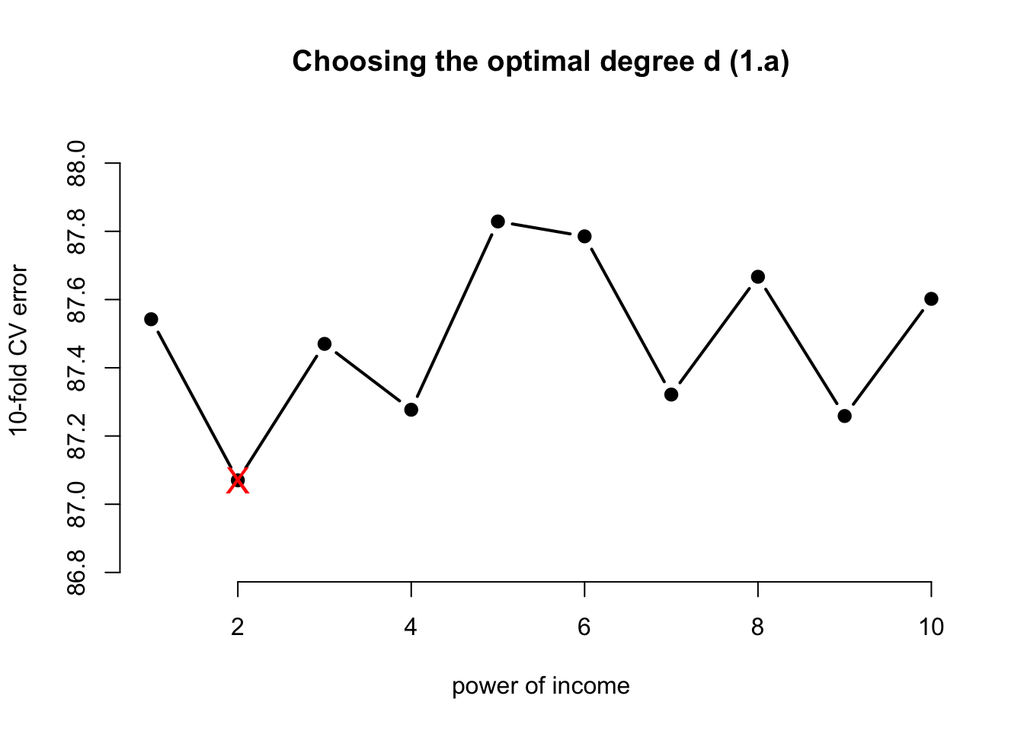

```r
seed = 317
cv.MSE<- rep(NA, 10)
for (i in 1:10) {
    glm.fit <- glm(egalit_scale ~ poly(income06, i), data = train)
    cv.MSE[i] <- cv.glm(train, glm.fit, K=10)$delta[1]}

plot( x = 1:10, y = cv.MSE, xlab = "power of income", ylab = "10-fold CV error",
      main = 'Choosing the optimal degree d (1.a)',
      type = "b", pch = 19, lwd = 2, bty = "n",
      ylim = c( min(cv.MSE) - sd(cv.MSE), max(cv.MSE) + sd(cv.MSE) ) )

points( x = which.min(cv.MSE), y = min(cv.MSE),
        col = "red", pch = "X", cex = 1.5 )
```

From diagram 1.a, we can see that the the relationship between the responsible variable $Y_{egalit_scale}$ and the predictive variable $X_{income06}$ in the gss-training data set is best modeled by the polynomial regression of degree 2. Equivalently, we get the optimal model with the expression:
$$Y= \beta_0 + \beta_1 X +\beta_2 X^2 + \epsilon$$

It’s worth to notice that $d=2$ is an acceptable value because generally, it is unusual to use d greater than 3 or 4 because for large values of d, the polynomial curve can become overly flexible and can take on some very strange shapes.

The diagram below (diagram 1.b) shows the resulting polynomial fit to the data and the AME (diagram 1.c)

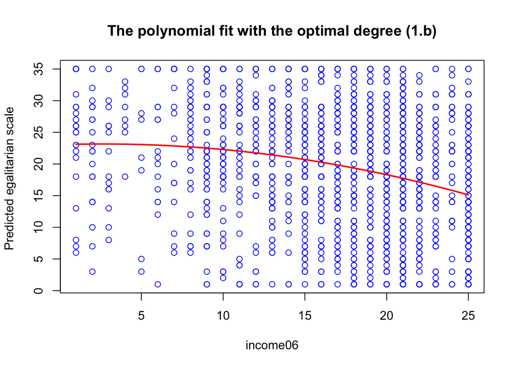

```r
range.income06 <- range(train$income06)
income06.grid <- seq(from = range.income06[1], to = range.income06[2])

fit <- lm(egalit_scale ~ stats::poly(income06, 2), data = train)
preds <- predict(fit, newdata = list(income06 = income06.grid))
plot(egalit_scale ~ income06,
     main = 'The polynomial fit with the optimal degree (1.b)',
     ylab = 'Predicted egalitarian scale ',
     data = train, col = "blue")
lines(income06.grid, preds, col = "red", lwd = 2)
```

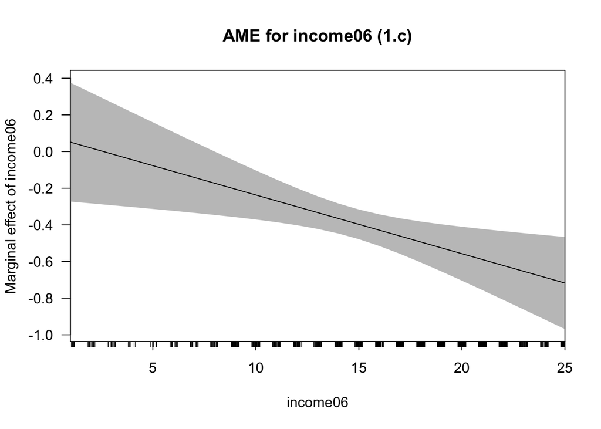

```r
cplot(fit,"income06",what = "effect",
      main= "AME for income06 (1.c)")
```

# Question 2

Choose the optimal number of cuts.

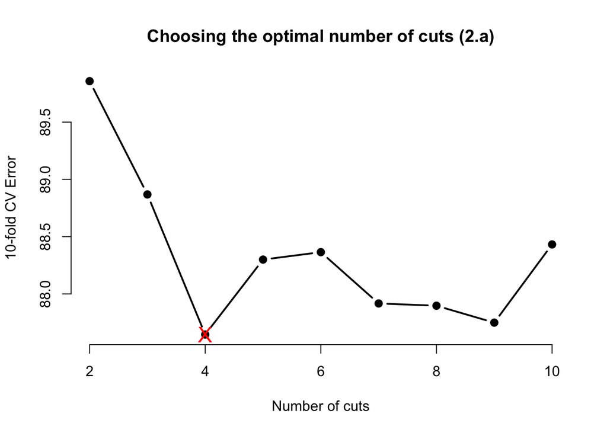

```r
cv.MSE <- rep(NA, 10)
# for each cut perform 10-fold cross-validation
for (i in 2:10) {
  train$income06.cut <- cut(train$income06, i)
  lm.fit <-  glm(egalit_scale ~ income06.cut, data = train)
  cv.MSE[i] <-  cv.glm(train, lm.fit, K = 10)$delta[1]
}
  plot(2:10, cv.MSE[-1], xlab = "Number of cuts", ylab = "10-fold CV Error",
       main = 'Choosing the optimal number of cuts (2.a)',
     type = "b", pch = 19, lwd = 2, bty ="n")

  points( x = which.min(cv.MSE), y = min( cv.MSE, na.rm = TRUE), col = "red", pch = "X", cex = 1.5 )
```

The diagram below (diagram 2.b) shows the resulting fit with the 4 number of cuts.

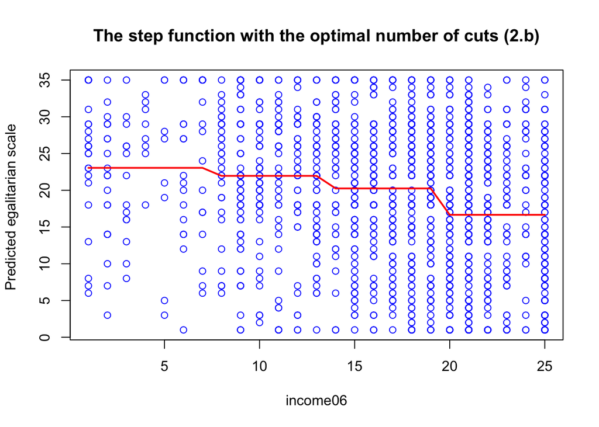

```r
fit  <- glm(egalit_scale~ cut(income06, 4), data = train)
preds <- predict(fit, data.frame(income06 = income06.grid))

plot(egalit_scale ~ income06, data = train, col = "blue",
     main = 'The step function with the optimal number of cuts (2.b)',
     ylab = 'Predicted egalitarian scale ')
lines(income06.grid, preds, col = "red", lwd = 2)
```

# Question 3

Select the optimal number of degrees of freedom

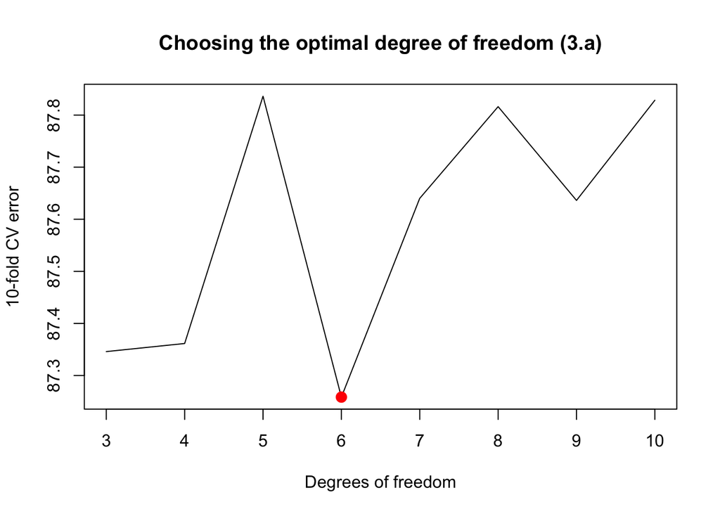

```r
library(splines)
set.seed(317)
cv.MSE <- rep(NA, 10)
for (i in 3:10) {
    fit <- glm(egalit_scale ~ ns(income06, df = i), data = train)
    cv.MSE[i] <- cv.glm(train, fit, K = 10)$delta[1]
}

plot(3:10, cv.MSE[-c(1, 2)], xlab = "Degrees of freedom", ylab = "10-fold CV error",
     main = 'Choosing the optimal degree of freedom (3.a)',type = "l")
d.min <- which.min(cv.MSE)
points(which.min(cv.MSE), cv.MSE[which.min(cv.MSE)], col = "red", cex = 2, pch = 20)
```

The diagram below (diagram 3.b) shows the resulting fit with the 6 df.

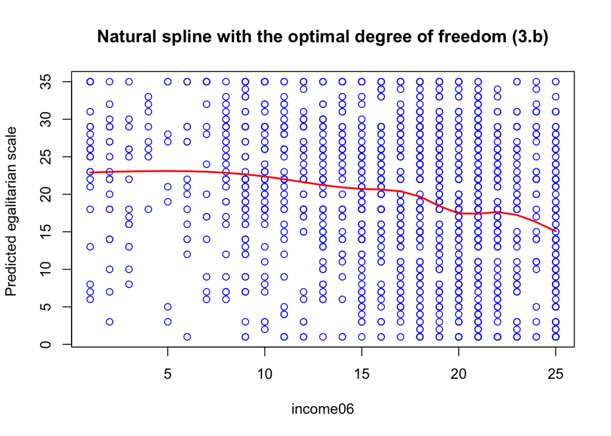

```r
fit <- glm(egalit_scale ~ ns(income06, df = 6), data = train)
preds <- predict(fit, data.frame(income06 = income06.grid))

plot(egalit_scale ~ income06, data = train, col = "blue",
     ylab = 'Predicted egalitarian scale ',
     main = 'Natural spline with the optimal degree of freedom (3.b)')
lines(income06.grid, preds, col = "red", lwd = 2)
```

# Question 4

## 4.a Linear Regression

```r
library(caret)

lm.fit=lm(egalit_scale~.,data=train.num)

pred<-predict(lm.fit,test.num)
print(lm.fit)
```

```
##
## Call:
## lm(formula = egalit_scale ~ ., data = train.num)
##
## Coefficients:
##      (Intercept)               age  authoritarianism            childs
##       -2.430e-16        -1.739e-01        -1.020e-01         4.070e-02
##         con_govt          income06      science_quiz              sibs
##        6.665e-02        -1.863e-01        -5.267e-03         9.601e-02
##   social_connect         tolerance           tvhours           wordsum
##       -8.891e-03        -3.307e-02         1.148e-01        -3.481e-03
```

```r
cat('MSE Value:', mean((pred-test.num$egalit_scale)^2))
```

```
## MSE Value: 0.934211
```

## 4.b Elastic Net

```r
train.mat <- model.matrix(egalit_scale ~ ., data = train.num)
test.mat <- model.matrix(egalit_scale ~ ., data = test.num)
for (i in seq(0, 1, .1))
{
  seed = 828
  cv.out <- cv.glmnet (train.mat,train.num$egalit_scale,alpha = i)
  bestlam <- cv.out$lambda.min
  model <- glmnet(train.mat,train.num$egalit_scale,alpha=1,
                  lambda=bestlam)
  pred <- predict(model,s = bestlam ,newx = test.mat)
  MSE <- mean((pred-test.num$egalit_scale)^2)
  cat('lambda:',bestlam,'alpha:',i,'MSE:',MSE,"\n")
}
```

```
## lambda: 0.09551428 alpha: 0 MSE: 0.9451387
## lambda: 0.04753768 alpha: 0.1 MSE: 0.9263993
## lambda: 0.03448452 alpha: 0.2 MSE: 0.9239863
## lambda: 0.01092196 alpha: 0.3 MSE: 0.9284271
## lambda: 0.02076836 alpha: 0.4 MSE: 0.9250796
## lambda: 0.01043451 alpha: 0.5 MSE: 0.9286376
## lambda: 0.01667704 alpha: 0.6 MSE: 0.9262646
## lambda: 0.01081335 alpha: 0.7 MSE: 0.9284737
## lambda: 0.005414321 alpha: 0.8 MSE: 0.9309797
## lambda: 0.006982446 alpha: 0.9 MSE: 0.9301586
## lambda: 0.006284202 alpha: 1 MSE: 0.9305154
```

```r
cv.out <- cv.glmnet (train.mat,train.num$egalit_scale,alpha = 0.3)
bestlam <- cv.out$lambda.min
net.model <- glmnet(train.mat,train.num$egalit_scale,alpha=1,
                  lambda=bestlam)
pred <- predict(net.model,s = bestlam ,newx = test.mat)
MSE <- mean((pred-test.num$egalit_scale)^2)
net.model
```

```
##
## Call:  glmnet(x = train.mat, y = train.num$egalit_scale, alpha = 1,      lambda = bestlam)
##
##   Df   %Dev  Lambda
## 1  8 0.1037 0.02769
```

```r
cat('MSE for Elastic Net:',MSE)
```

```
## MSE for Elastic Net: 0.9237217
```

## 4.c Principal component regression

```r
library(pls)
```

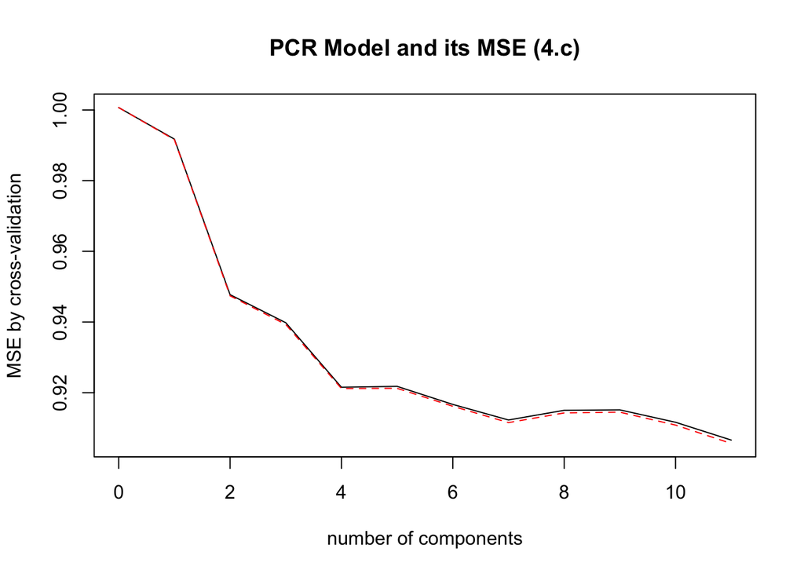

```r
pcr_model <- pcr(egalit_scale~., data = train.num, scale = TRUE, validation = "CV")
validationplot(pcr_model,val.type = 'MSEP',
               main = 'PCR Model and its MSE (4.c)',
               ylab = 'MSE by cross-validation')
```

```r
summary(pcr_model)
```

```
## Data:    X dimension: 1481 11
##  Y dimension: 1481 1
## Fit method: svdpc
## Number of components considered: 11
##
## VALIDATION: RMSEP
## Cross-validated using 10 random segments.
##        (Intercept)  1 comps  2 comps  3 comps  4 comps  5 comps  6 comps
## CV               1   0.9959   0.9735   0.9694   0.9600   0.9601   0.9574
## adjCV            1   0.9958   0.9734   0.9692   0.9598   0.9598   0.9572
##        7 comps  8 comps  9 comps  10 comps  11 comps
## CV      0.9551   0.9566   0.9566    0.9548    0.9522
## adjCV   0.9547   0.9562   0.9563    0.9544    0.9516
##
## TRAINING: % variance explained
##               1 comps  2 comps  3 comps  4 comps  5 comps  6 comps  7 comps
## X              24.833   38.049   47.826   56.760   64.917   72.314   78.633
## egalit_scale    1.072    5.697    6.631    8.548    8.874    9.282    9.768
##               8 comps  9 comps  10 comps  11 comps
## X               84.58   90.377     95.45    100.00
## egalit_scale     9.77    9.781     10.26     11.09
```

Diagram 4.c shows that when the number of components is 11, the model generate the best result. However, since too many components may overfit the data, it’s safe to take number of components as 7.

```r
pcr.pred=predict(pcr_model,test.num,ncomp=7)
cat('MSE for PCR:',mean((pcr.pred-test.num$egalit_scale)^2))
```

```
## MSE for PCR: 0.9275542
```

## 4.d Partial least squares regression

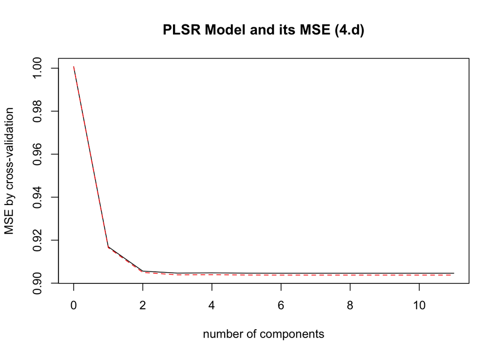

```r
library(pls)
pls_model <- plsr(egalit_scale~., data = train.num, scale = TRUE, validation = "CV")
validationplot(pls_model,val.type = 'MSEP',
               main = 'PLSR Model and its MSE (4.d)',
               ylab = 'MSE by cross-validation')
```

```r
summary(pls_model)
```

```
## Data:    X dimension: 1481 11
##  Y dimension: 1481 1
## Fit method: kernelpls
## Number of components considered: 11
##
## VALIDATION: RMSEP
## Cross-validated using 10 random segments.
##        (Intercept)  1 comps  2 comps  3 comps  4 comps  5 comps  6 comps
## CV               1   0.9576   0.9516   0.9511   0.9512   0.9511   0.9511
## adjCV            1   0.9574   0.9513   0.9507   0.9507   0.9507   0.9507
##        7 comps  8 comps  9 comps  10 comps  11 comps
## CV      0.9511   0.9511   0.9511    0.9511    0.9511
## adjCV   0.9507   0.9507   0.9507    0.9507    0.9507
##
## TRAINING: % variance explained
##               1 comps  2 comps  3 comps  4 comps  5 comps  6 comps  7 comps
## X              16.592    35.02    44.67    51.99    59.34    66.97    73.77
## egalit_scale    9.229    10.70    11.05    11.09    11.09    11.09    11.09
##               8 comps  9 comps  10 comps  11 comps
## X               80.51    88.19     94.07    100.00
## egalit_scale    11.09    11.09     11.09     11.09
```

```r
pls.pred=predict(pls_model,test.num,ncomp=2)
cat('MSE for PLS:',mean((pls.pred-test.num$egalit_scale)^2))
```

```
## MSE for PLS: 0.9269083
```

In question 4, MSE values for elastic net, PCR and PLS are in the range of 0.92-0.93 , which are not significantly different from each other. Thus, I do think these four models’ performances are approximately equal. The MSE value for linear regression is slihghtly higher around 0.935, which means the other three models perform slightly better than it does.

# Question 5

## 5.1.a Linear regression

```r
library(vip)
library(pdp)
library(devtools)
```

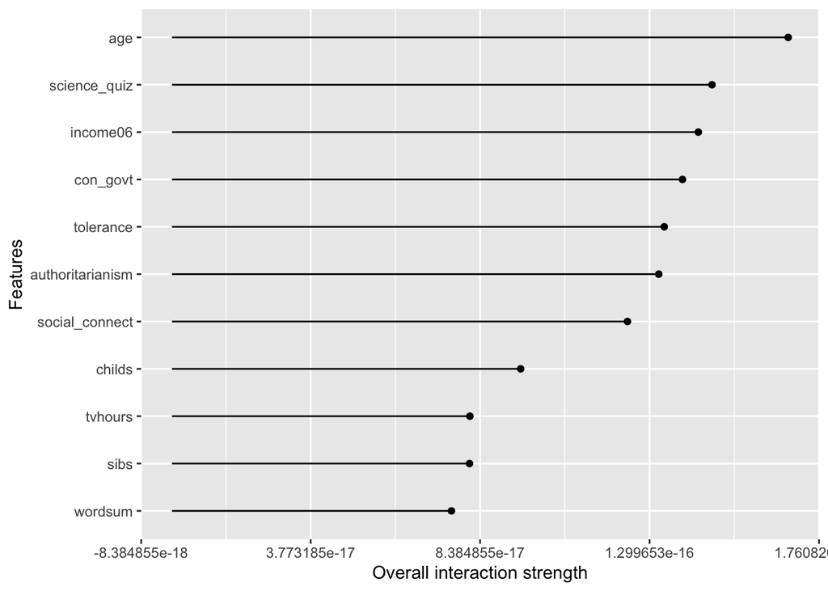

```r
library(iml)

features = train.num %>% dplyr::select(-egalit_scale)
response = as.numeric(as.vector(train.num$egalit_scale))

predictor.lm = Predictor$new(model = lm.fit,data = features, y=response)
plot(Interaction$new(predictor.lm))
```

## 5.1.b Elastic Net

```r
net = train(
    egalit_scale ~ ., data = train.num, method = "glmnet",
    tuneLength = 10)
```

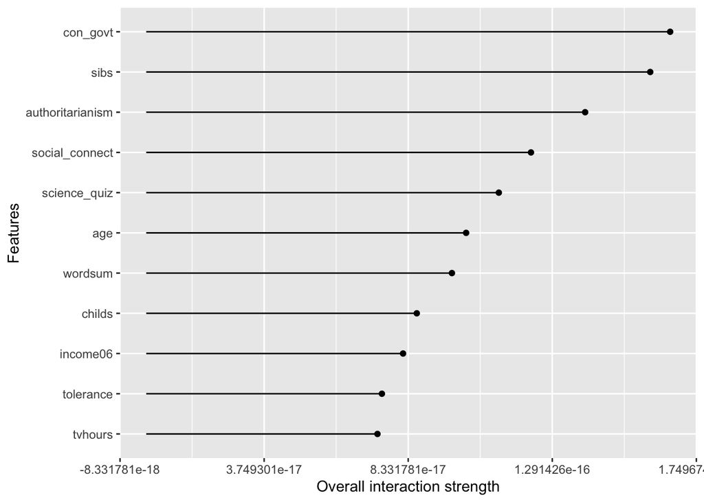

```r
net.best = train(
    egalit_scale ~ ., data = test.num, method = "glmnet",
     tuneGrid = expand.grid(alpha = net$bestTune$alpha,
                            lambda = net$bestTune$lambda))

predictor.net = Predictor$new(model = net.best,data = features, y=response)
plot(Interaction$new(predictor.net))
```

## 5.1.c PCR

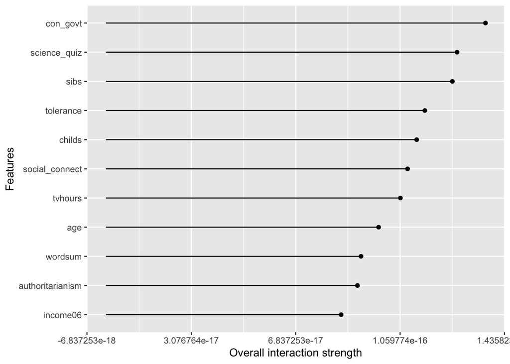

```r
folds = trainControl(method = "cv", number = 10)
pcr = train(
    egalit_scale ~ ., data = train.num, method = "pcr",
    tuneLength = 10)
pcr.best = train(
    egalit_scale ~ ., data = test.num, method = "pcr",
    tuneGrid = expand.grid(ncomp = pcr$bestTune$ncomp))

predictor.pcr = Predictor$new(model = pcr.best,data = features, y=response)
plot(Interaction$new(predictor.pcr))
```

## 5.1.d PLS

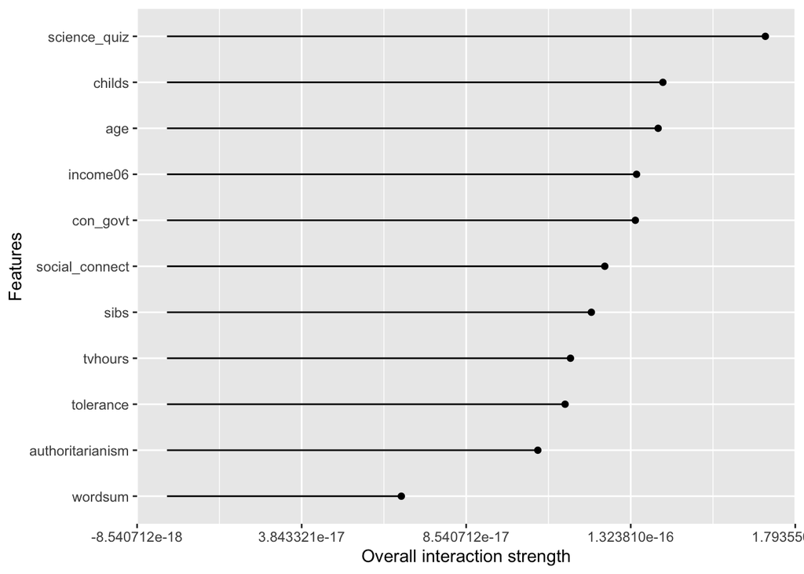

```r
pls = train(
    egalit_scale ~ ., data = train.num, method = "pls",
    tuneLength = 10)
pls.best = train(
    egalit_scale ~ ., data = test.num, method = "pls",
    tuneGrid = expand.grid(ncomp = pls$bestTune$ncomp))

predictor.pls = Predictor$new(model = pls.best,data = features, y=response)
plot(Interaction$new(predictor.pls))
```

which means,he variation of the prediction depends heavilyon the interaction of thease features.

# 5.2 Feature Importance

Here’s another measurement.

## 5.2.a lm

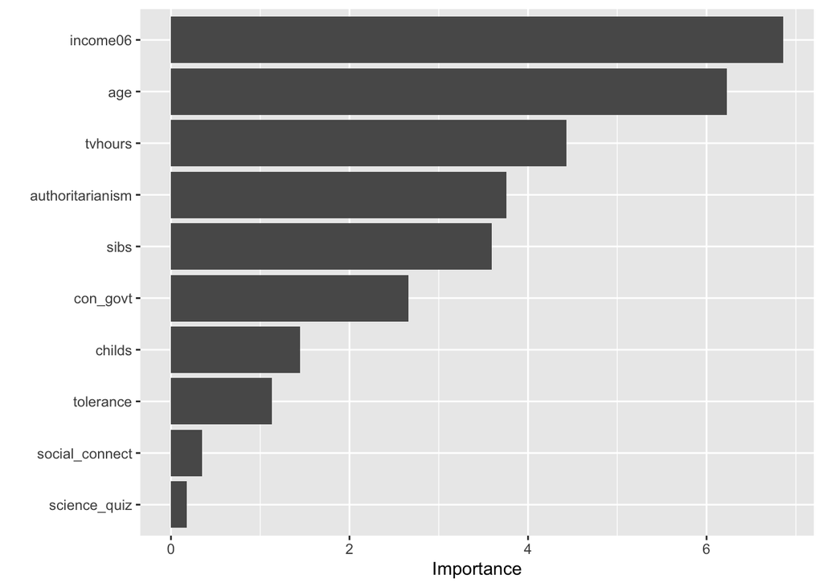

```r
vip(lm.fit)
```

##5.2.b Elastic Net

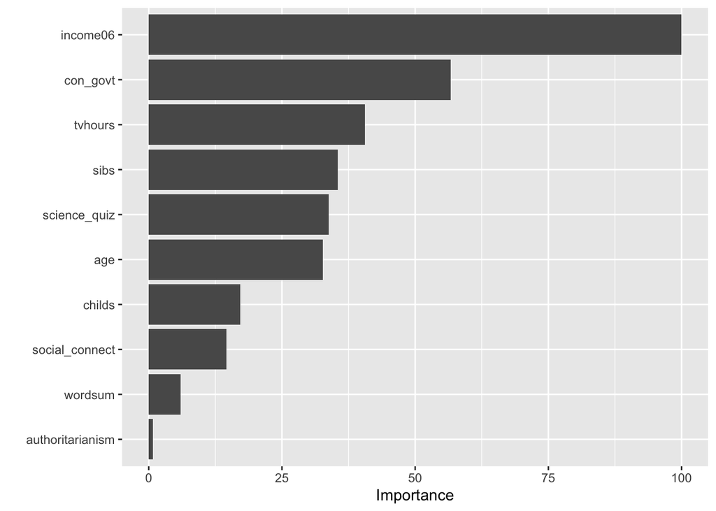

```r
vip(net.best)
```

## 5.2.c PCR

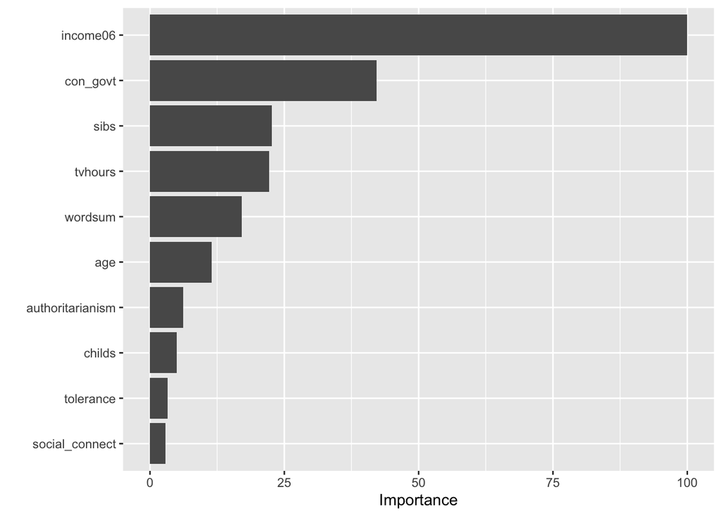

```r
vip(pcr.best)
```

## 5.2.d PLS

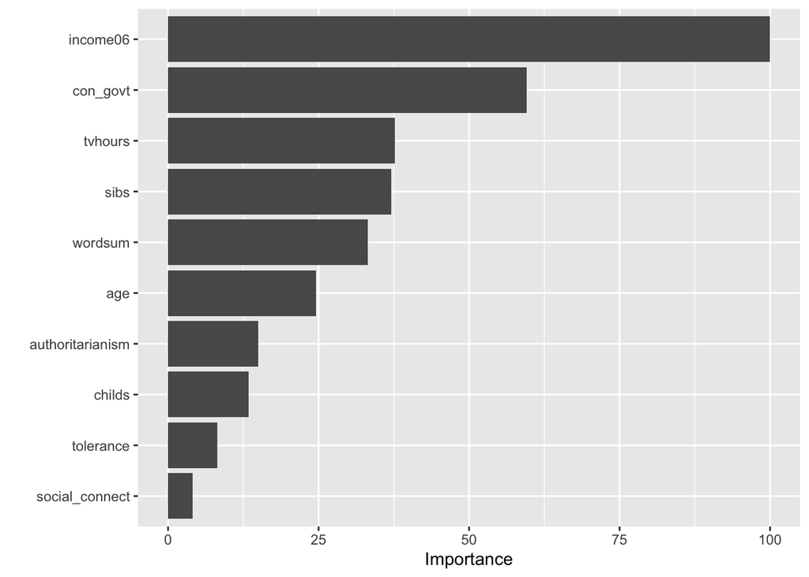

```r
vip(pls.best)
```

From above diagrams, the most important features for each models are:

Linear regression: income06,age,tvhours

Elastic net regression: income06,con_govt,tvhours

Principal component regression (for ncomps =7):income06,con_govt,sibs

Partial least squares regression (for ncomps = 2): income06,con_govt,tvhours

INCOME06(4),TVHOURS (3), CON_GOVT(3)

The feature importance indicates the variance of the partial dependence functionconditional on the other feature. Higher the variance, stronger the features interaction with each other. THerefore, above three predictors have strong interaction with each other.